# Annual Developer Survey

49370 rows × 24 columns

The pandas series **DevType_share** was defined before.

```python
DevType_share
```

```
Marketing_or_sales_professional                  0.013004
Senior_executive_VP                              0.026737
Engineer_site_reliability                        0.039295
Scientist                                        0.042252
Product_manager                                  0.050577
Engineering_manager                              0.055175
Developer_game_or_graphics                       0.056492
Educator                                         0.059307
Academic_researcher                              0.071947
Engineer_data                                    0.075714
Developer_QA_or_test                             0.079947
Data_scientist_or_machine_learning_specialist    0.080778
Data_or_business_analyst                         0.081507
Developer_embedded_applications_or_devices       0.096212
System_administrator                             0.106178
Designer                                         0.107778
Database_administrator                           0.115900
DevOps_specialist                                0.120903
Developer_mobile                                 0.192060
Developer_desktop_or_enterprise_applications     0.238687
Developer_frontend                               0.370589
Developer_fullstack                              0.549423
Developer_backend                                0.551509
dtype: float64
```

Let us produce a nice looking chart for the share of each developer role.

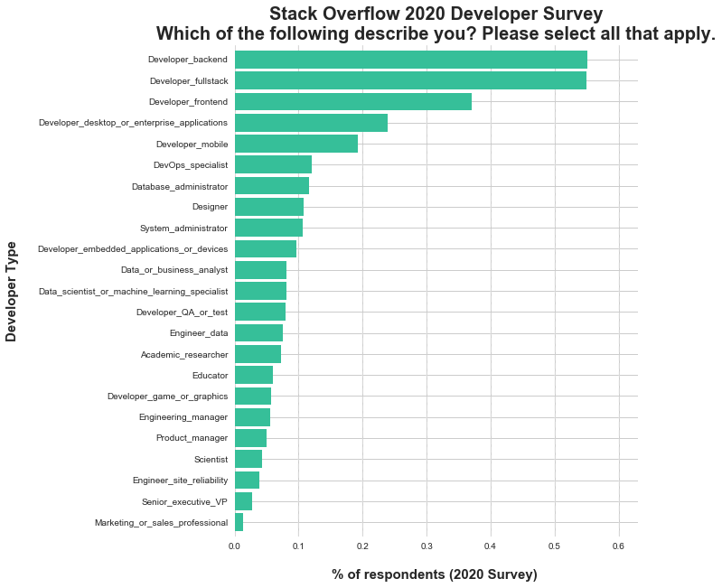

```
# of respondants:  49370
On average developers have 3.2 roles.
```

```python
# DevType_share was defined before

ax = DevType_share.plot(kind='barh', figsize=(8, 10), color='#36bf99', zorder=2, width=0.85)

  # Despine
ax.spines['right'].set_visible(False)
ax.spines['top'].set_visible(False)
ax.spines['left'].set_visible(False)
ax.spines['bottom'].set_visible(False)

  # Switch off ticks
ax.tick_params(axis="both", which="both", bottom="off", top="off", labelbottom="on", left="off", right="off", labelleft="on")

  # Draw vertical axis lines
vals = ax.get_xticks()
for tick in vals:
    ax.axvline(x=tick, linestyle='dashed', alpha=0.4, color='#eeeeee', zorder=1)

  # Set x-axis label
ax.set_xlabel("% of respondents (2020 Survey) ", labelpad=20, weight='bold', size=15)

  # Set y-axis label
ax.set_ylabel("Developer Type", labelpad=20, weight='bold', size=15)

plt.title('Stack Overflow 2020 Developer Survey\nWhich of the following describe you? Please select all that apply.', weight='bold', size=20);
plt.show()
print('# of respondants: ', df2020_DevType.shape[0])
print('On average developers have',round(sum(DevType_share),1), 'roles.')
```

The **49,370 respondants** could choose more than option in this question (i.e. select all that apply). On average, developers picked 3.2 developer types to describe their roles. We're interested in the approx. 8 percent of respondants who picked the `[Data_scientist_or_machine_learning_specialist]` option.

# Research Question No.1

```python
df2020_DSML = df2020_DevType[df2020_DevType['Data_scientist_or_machine_learning_specialist']].mean().sort_values()
df2020_DSML
```

```
Marketing_or_sales_professional                  0.030592
Senior_executive_VP                              0.054915
Engineer_site_reliability                        0.057924
Developer_game_or_graphics                       0.077232
Engineering_manager                              0.081244
Product_manager                                  0.082247
Developer_QA_or_test                             0.085256
Designer                                         0.113842
Educator                                         0.122869
Developer_embedded_applications_or_devices       0.128385
System_administrator                             0.133902
DevOps_specialist                                0.141424
Developer_mobile                                 0.142678
Database_administrator                           0.188816
Developer_desktop_or_enterprise_applications     0.194082
Developer_frontend                               0.223420
Scientist                                        0.224423
Academic_researcher                              0.279840
Engineer_data                                    0.297894
Data_or_business_analyst                         0.325226
Developer_fullstack                              0.371866
Developer_backend                                0.472668
Data_scientist_or_machine_learning_specialist    1.000000
dtype: float64
```

Let us create a nice looking chart.

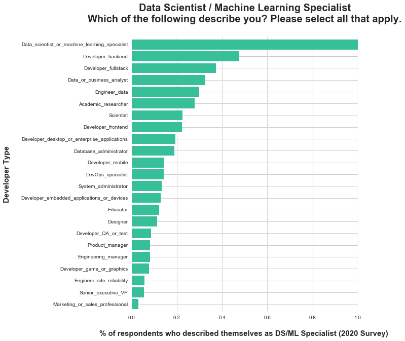

```
# of  Respondent    3988
dtype: int64
Data_scientist_or_machine_learning_specialist    1.000000
Developer_backend                                0.472668
Developer_fullstack                              0.371866
Data_or_business_analyst                         0.325226
Engineer_data                                    0.297894
dtype: float64
```

```python
ax = df2020_DSML.plot(kind='barh', figsize=(8, 10), color='#36bf99', zorder=2, width=0.85)

  # Despine
ax.spines['right'].set_visible(False)
ax.spines['top'].set_visible(False)
ax.spines['left'].set_visible(False)
ax.spines['bottom'].set_visible(False)

  # Switch off ticks
ax.tick_params(axis="both", which="both", bottom="off", top="off", labelbottom="on", left="off", right="off", labelleft="on")

  # Draw vertical axis lines
vals = ax.get_xticks()
for tick in vals:
    ax.axvline(x=tick, linestyle='dashed', alpha=0.4, color='#eeeeee', zorder=1)

  # Set x-axis label
ax.set_xlabel("% of respondents who described themselves as DS/ML Specialist (2020 Survey) ", labelpad=20, weight='bold', size=15)

  # Set y-axis label
ax.set_ylabel("Developer Type", labelpad=20, weight='bold', size=15)


plt.title('Data Scientist / Machine Learning Specialist\nWhich of the following describe you? Please select all that apply.\n'\
          , weight='bold', size=20);
plt.xlim([0, 1])
plt.show()
print('# of ', df2020_clean[df2020_clean['Data_scientist_or_machine_learning_specialist']].count().head(1))
print(df2020_DSML.tail().sort_values(ascending=False))
```

In the 2020 developer survey, 3988 developers or **8.1 percent** of the survey respondants perform the role of Data Scientists or Machine Learning specialists. How many additional developer roles do they perform?

```python
print('On average, Data Scientist/Machine Learning Specialist have',round(df2020_DSML.sum()-1,1), \
      'additional developer roles.')
```

```
On average, Data Scientist/Machine Learning Specialist have 3.8 additional developer roles.
```

</font>

### Data Scientist/Machine Learning Specialist frequently perform additional software developer roles as well.

> Almost half are `[Developer backend]` and 37 % are `[Developer fullstack]`.

> Other popular developer roles performed are
> - `[Data or business analyst]` ( 33 %)
> - `[Engineer data]` ( 30 %).
> - About a third are `[Academic researcher]` or `[Scientist]`

</font>

## Research Question No.2

> What programming languages do **Data Scientist/Machine Learning Specialist** use?
- Create a new pandas series that consists of the mean values of each of the 25 columns with boolean type mapped from the variable **`df2020`** `LanguageWorkedWith` *and* take only observations where `[Data_scientist_or_machine_learning_specialist]` == True .

```python
# Create a new pandas series
DSML_languages = (df2020_clean[df2020_clean['Data_scientist_or_machine_learning_specialist']].mean().tail(25)).sort_values()
DSML_languages
```

```
Dart;                     0.033601
Haskell;                  0.036610
Objective-C;              0.038114
Julia;                    0.042377
Perl;                     0.044132
Swift;                    0.046891
Kotlin;                   0.059178
Rust;                     0.062187
Ruby;                     0.064193
Assembly;                 0.075226
Scala;                    0.083751
VBA;                      0.093280
Go;                       0.095537
TypeScript;               0.139920
PHP;                      0.180040
C#;                       0.213390
C;                        0.250502
R;                        0.276329
C++;                      0.297894
Java;                     0.350552
Bash/Shell/PowerShell;    0.395687
HTML/CSS;                 0.482447
JavaScript;               0.482698
SQL;                      0.584504
Python;                   0.783350
dtype: float64
```

How many languages do Data Scientist/Machine Learning Specialist use on average?

```python
DSML_languages.sum()
```

```
5.212387161484454
```

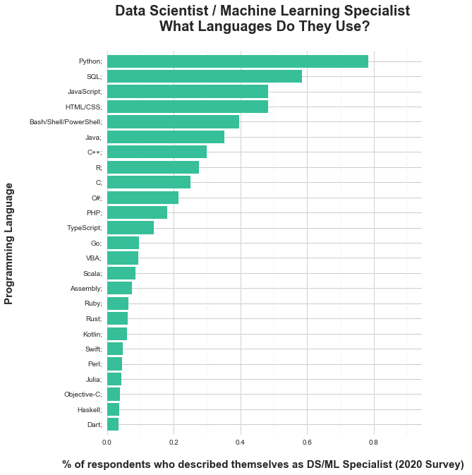

```
Respondent    3988
dtype: int64

On average, Data Scientist/Machine Learning Specialists use 5.2 programming, scripting, and markup languages.
```

```python
ax = DSML_languages.plot(kind='barh', figsize=(8, 10), color='#36bf99', zorder=2, width=0.85)

  # Despine
ax.spines['right'].set_visible(False)
ax.spines['top'].set_visible(False)
ax.spines['left'].set_visible(False)
ax.spines['bottom'].set_visible(False)

  # Switch off ticks
ax.tick_params(axis="both", which="both", bottom="off", top="off", labelbottom="on", left="off", right="off", labelleft="on")

  # Draw vertical axis lines
vals = ax.get_xticks()
for tick in vals:
    ax.axvline(x=tick, linestyle='dashed', alpha=0.4, color='#eeeeee', zorder=1)

  # Set x-axis label
ax.set_xlabel("% of respondents who described themselves as DS/ML Specialist (2020 Survey) ", labelpad=20, weight='bold', size=15)

  # Set y-axis label
ax.set_ylabel("Programming Language", labelpad=20, weight='bold', size=15)

  # Format y-axis label
#ax.xaxis.set_major_formatter(StrMethodFormatter('{x:,g}'))

plt.title('Data Scientist / Machine Learning Specialist \nWhat Languages Do They Use?\n', weight='bold', size=20);
plt.show()
print((df2020_clean[df2020_clean['Data_scientist_or_machine_learning_specialist']]).count().head(1))
print('\nOn average, Data Scientist/Machine Learning Specialists use',round(DSML_languages.sum(),1), \
      'programming, scripting, and markup languages.')
```

</font>

## Data Scientist/Machine Learning Specialists

> **- Python** is by far the most popular programming language for Data Science and Machine Learning.
> - Structured Query Language **(SQL)** is used by 60 %
> - Half use the languages **HTML/CSS** and **JavaScript** for web development
> - 40 % use **Bash/Shell/PowerShell** for command line Interface.
> - 28 % use the **R language** for data analysis
> - 9 % use Visual Basic for Applications (**VBA**)
> - Already 4 % use **Julia** , a language that first appeared in 2012

</font>

## Research Question No.3

> What is the correlation between technologies used by all respondants of the 2020 survey ?

> **MiscTechWorkedWith**: Which other frameworks, libraries, and tools have you done extensive development work in over the past year?

Let us create a headmap to show the correlation between technologies used.

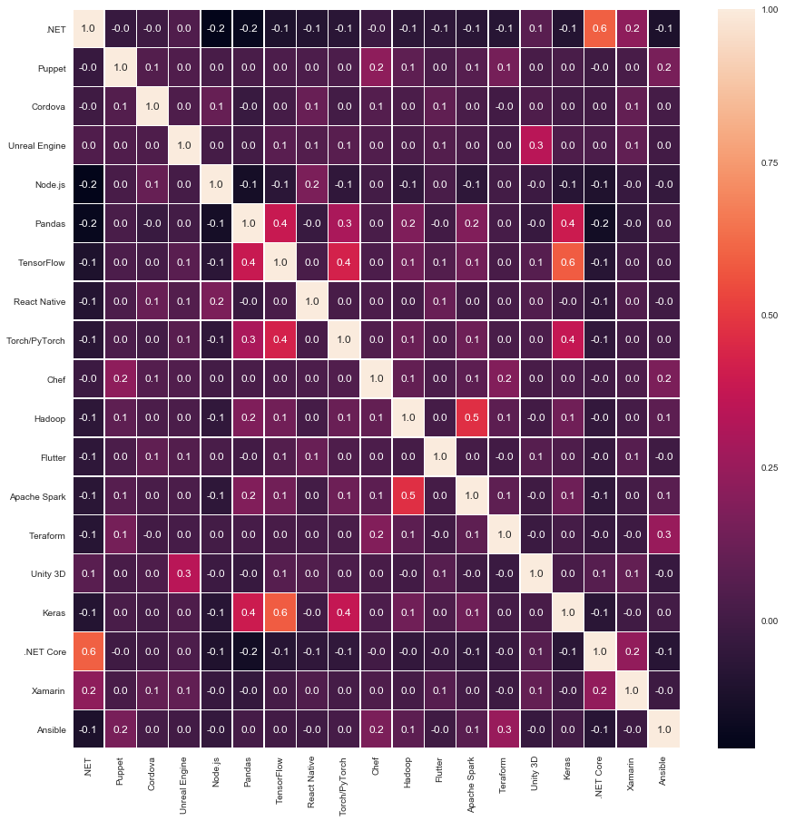

```python
ig, ax = plt.subplots(figsize=(15,15))         # Sample figsize in inches

sns.heatmap(df2020_MiscTechWorkedWith.corr(), annot=True, fmt=".1f", linewidths=.5);
```

</font>

## Pairs of technologies that are highly correlated

> *[Machine Learning]*
> > - `[Keras]` and `[TensorFlow]` (**correlation 0.6**)
> > - `[Torch/PyTorch]` and `[Keras]` (**correlation 0.4**)
> > - `[Torch/PyTorch]` and `[TensorFlow]` (**correaltion 0.4**).

> *[Big Data]*
> > - `[Apache Spark]` and `[Hadoop]` (**correlation 0.5**)

## Research Question No.3

> What technologies do **Data Scientist/Machine Learning Specialist** use?
- Create a new pandas series that consists of the mean values of each of the 19 columns with boolean type mapped from the variable **`df2020`** `MiscTechWorkedWith` *and* take only observations where `[Data_scientist_or_machine_learning_specialist]` == True .

```python
#
DSML_MiscTechWorkedWith = df2020_clean[df2020_clean['Data_scientist_or_machine_learning_specialist']].filter(
    [".NET" , "Puppet" ,"Cordova" , "Unreal Engine", "Node.js", "Pandas", "TensorFlow" ,
     "React Native" , "Torch/PyTorch" ,  "Chef" , "Hadoop" , "Flutter" ,
     "Apache Spark" , "Teraform", "Unity 3D" , "Keras" ,
     ".NET Core" , "Xamarin" , "Ansible" ], axis=1).mean().sort_values()
```

The pandas series should show the percentage share of each technology.

```python
DSML_MiscTechWorkedWith
```

```
Chef             0.020812
Puppet           0.024323
Unreal Engine    0.027583
Xamarin          0.035858
Cordova          0.037613
Flutter          0.047894
Teraform         0.051655
Ansible          0.060933
Unity 3D         0.066449
React Native     0.072467
Hadoop           0.129639
.NET Core        0.134403
Apache Spark     0.156971
.NET             0.172016
Torch/PyTorch    0.198345
Node.js          0.256520
Keras            0.272568
TensorFlow       0.379388
Pandas           0.500752
dtype: float64
```

Let us create a nice looking chart.

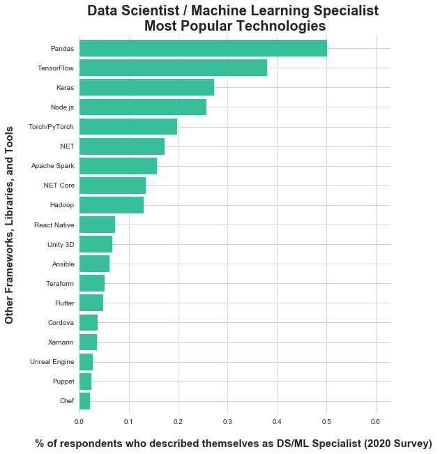

```
On average DS/ML Specialists use  2.6 technologies.
```

```python
ax = DSML_MiscTechWorkedWith.plot(kind='barh', figsize=(8, 10), color='#36bf99', zorder=2, width=0.85)

# Despine
ax.spines['right'].set_visible(False)
ax.spines['top'].set_visible(False)
ax.spines['left'].set_visible(False)
ax.spines['bottom'].set_visible(False)

  # Switch off ticks
ax.tick_params(axis="both", which="both", bottom="off", top="off", labelbottom="on", left="off", right="off", labelleft="on")

  # Draw vertical axis lines
vals = ax.get_xticks()
for tick in vals:
    ax.axvline(x=tick, linestyle='dashed', alpha=0.4, color='#ffffff', zorder=1)

  # Set x-axis label
ax.set_xlabel("% of respondents who described themselves as DS/ML Specialist (2020 Survey) ", labelpad=20, weight='bold', size=15)

  # Set y-axis label
ax.set_ylabel("Other Frameworks, Libraries, and Tools", labelpad=20, weight='bold', size=15)

  # Format y-axis label
#ax.xaxis.set_major_formatter(StrMethodFormatter('{x:,g}'))

plt.title('Data Scientist / Machine Learning Specialist \nMost Popular Technologies', weight='bold', size=20);
plt.show()

print('On average DS/ML Specialists use ',round(sum(DSML_MiscTechWorkedWith),1), 'technologies.')
```

</font>

### The most popular technologies used by Data Scientist/Machine Learning Specialist are:

> > **(1)** `[Pandas]` (50 %)  
> > **(2)** `[Tensorflow]` (38 %)

> > **(3)** `[Keras]`(27 %)

> > **(4)** `[Node.js]`(26 %)

> > **(5)** `[Torch/PyTorch]`(20 %)

>  
</font>

## Correlation between languages

> What is the correlation between languages used by all respondants of the 2020 survey ?

> **LanguageWorkedWith**: Which programming, scripting, and markup languages have you done extensive development work in over the past year, and which do you want to work in over the next year? (If you both worked with the language and want to continue to do so, please check both boxes in that row.)

We will be using the dataframe **`df2020_LanguageWorkedWith`** that consists of the column `LanguageWorkedWith` and the 25 boolean variables mapped from **`df2020`** `LanguageWorkedWith`.

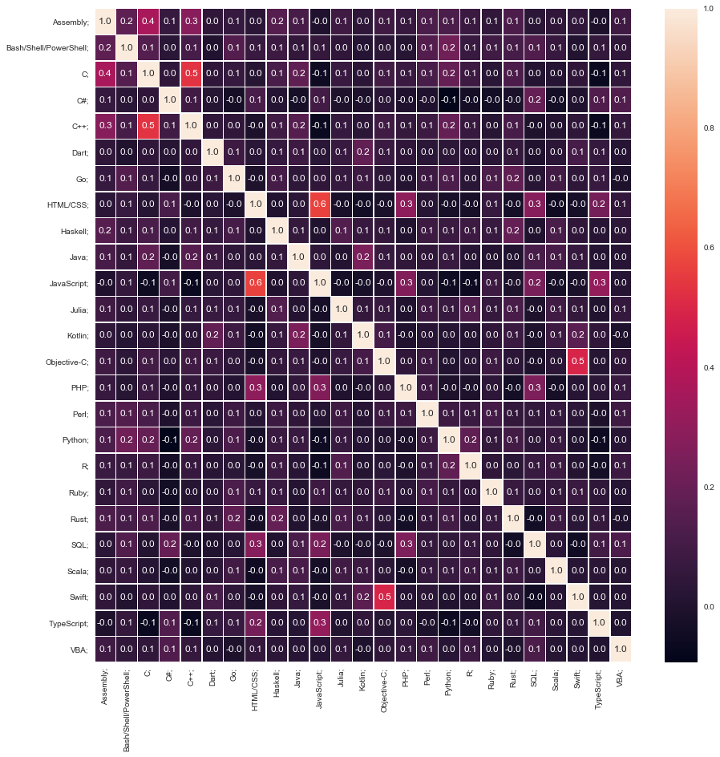

```python
ig, ax = plt.subplots(figsize=(15,15))         # Sample figsize in inches
#sns.heatmap(df1.iloc[:, 1:6:], annot=True, linewidths=.5, ax=ax)

sns.heatmap(df2020_LanguageWorkedWith.corr(), annot=True, fmt=".1f", linewidths=.5);
```

</font>

## Pairs of programming, scripting, and markup languages that are highly correlated

> *[Web Design]*

> > There is a strong **correlation of 0.6** between `[HTML/CSS]` and `[JavaScript]`

> *[Language designers: Apple]*

> > `[Objective-C]` and `[Swift]` (**correlation 0.5**)

> *[Using Assembly Language and C/C++]*

> > `[C]` and `[C++]` (**correlation 0.5**)

> > `[C]` and `[Assembly]` (**correlation 0.4**).

# V. Intertemporal exploration

Let us now turn to changes is the popularity of programming, scripting, and markup languages.

## Research Question No.4

What programming, scripting, and markup languages are gaining popularity in 2020 compared to 2018 ? >

> **LanguageWorkedWith**: Which programming, scripting, and markup languages have you done extensive development work in over the past year?

> **LanguageDesireNextYear**: Which programming, scripting, and markup languages do you want to work in over the next year?

**First**, we would like to compare the shares of languages used by developers in 2018 and 2020. We have already calculated the share of the 38 and the 25 programming languages for **`df2018`** `LanguageWorkedWith` and **`df2020`** `LanguageWorkedWith` , respectively.

```python
# turn a pandas series into a dataframe
props_df2018            = df2018_LanguageWorkedWith_share.to_frame(name='count')
props_df2018.index.name = 'language'
props_df2018            =  props_df2018.iloc[::-1] #  reverse the order

# turn a pandas series into a dataframe
props_df2020            = df2020_LanguageWorkedWith_share.to_frame(name='count')
props_df2020.index.name = 'language'
props_df2020            = props_df2020.iloc[::-1] #  reverse the order
```

Let us compare the share of each programming language common to both surveys.

```python
print('\nWhich programming, scripting, and markup languages have you done \nextensive development work in over the past year?')
comp_df = pd.merge(props_df2018, props_df2020, left_index=True, right_index=True)
comp_df.columns = ['2018', '2020']
comp_df['Diff'] = comp_df['2020'] - comp_df['2018']
comp_df.style.bar(subset=['Diff'], align='mid', color=['#d65f5f', '#5fba7d'])
```

```
Which programming, scripting, and markup languages have you done
extensive development work in over the past year?
```

| language | 2018 | 2020 | Diff |
| --- | --- | --- | --- |
| JavaScript; | 0.698113 | 0.676601 | -0.0215124 |
| SQL; | 0.57025 | 0.547475 | -0.0227758 |
| Java; | 0.453456 | 0.40214 | -0.0513155 |
| Python; | 0.387558 | 0.440709 | 0.0531506 |
| C#; | 0.344091 | 0.314424 | -0.029667 |
| PHP; | 0.307287 | 0.261546 | -0.0457405 |
| C++; | 0.253683 | 0.238889 | -0.0147935 |
| C; | 0.230321 | 0.217627 | -0.0126945 |
| TypeScript; | 0.173947 | 0.25407 | 0.080122 |
| Ruby; | 0.100991 | 0.0705148 | -0.0304758 |
| Swift; | 0.0805525 | 0.0592039 | -0.0213486 |
| Assembly; | 0.0735313 | 0.0619227 | -0.0116086 |
| Go; | 0.0706207 | 0.0878037 | 0.017183 |
| Objective-C; | 0.0703398 | 0.0407822 | -0.0295576 |
| R; | 0.061442 | 0.0573042 | -0.00413784 |
| VBA; | 0.0486379 | 0.0609816 | 0.0123437 |
| Kotlin; | 0.0447826 | 0.0778696 | 0.033087 |
| Scala; | 0.0436592 | 0.0357628 | -0.00789637 |
| Perl; | 0.041872 | 0.0313012 | -0.0105708 |
| Haskell; | 0.0250338 | 0.0212974 | -0.00373647 |
| Rust; | 0.0237062 | 0.0510474 | 0.0273413 |
| Julia; | 0.00548931 | 0.00904528 | 0.00355596 |

Unfortunatly, there are only 22 languages shown here.

Three language options from **`df2020`** `LanguageWorkedWith` are missing:

- `[Bash/Shell/PowerShell]` ,
- `[HTML/CSS]` and
- `[Dart]` .

There is some mismatch between the options in 2018 and 2020

> **`df2018`** `LanguageWorkedWith` only listed the option `[Bash/Shell]` and not `[Bash/Shell/PowerShell]`

> **`df2018`** `LanguageWorkedWith` listed two seperate option `[HTML]` and `[CSS]`

> **`df2018`** `LanguageWorkedWith` does not include the option `[Dart]`

> **Dart** is an object-oriented, class-based, garbage-collected language with C-style syntax. It is developed by Google and it was unveiled at the GOTO conference in Aarhus, Denmark, October 10–12, 2011. https://en.wikipedia.org/wiki/Dart_(programming_language)

Let us create a list of all the programming languages in the two surveys 2018 and 2020. This could easily be accomplished by the union of the two sets of languages for the 2018 and 2020 surveys.

However, we want to ammend the list of languages by including **'Bash/Shell'** and **'HTML'** without a semi-colon at the end.

> This way, we should find entries in both
> - **`df2018`** `LanguageWorkedWith` `[Bash/Shell]` and **`df2020`** `LanguageWorkedWith` `[Bash/Shell/Powershell]`

> and
> - **`df2020`** `LanguageWorkedWith` `[HTML]` and **`df2020`** `LanguageWorkedWith` `[HTML/CSS]`

```python
programming_language = ["Assembly;", "Bash/Shell", "Bash/Shell/PowerShell;", "C;", "C#;", "C++;", 'CSS;','Clojure;','Cobol;',
                        'CoffeeScript;','Dart;','Delphi/Object Pascal;','Erlang;','F#;','Go;','Groovy;','HTML', 'HTML/CSS;',
                        'Hack;','Haskell;', 'Java;', 'JavaScript;','Julia;','Kotlin;','Lua;', 'Matlab;', 'Objective-C;','Ocaml;',
                        'PHP;', 'Perl;', 'Python;','R;','Ruby;','Rust;','SQL;','Scala;','Swift;', 'TypeScript;', 'VB.NET','VBA;',
                        'Visual Basic 6;']
```

We drop all rows with NANs in the variabel `[LanguageWorkedWith]` in both surveys.

```python
df2018_clean = df2018_clean.dropna(subset=['LanguageWorkedWith'], axis=0)
df2020_clean = df2020_clean.dropna(subset=['LanguageWorkedWith'], axis=0)
df2020_clean.shape
```

```
(57378, 126)
```

Helper function

```python
def props_languages(df):
    '''
    INPUT
        df - a dataframe holding the LanguageWorkedWith and LanguageDesireNextYear columns

    OUTPUT
        props_LanguageWorkedWith_df     - a dataframe with the share of each programming language worked with this year
        props_LanguageDesireNextYear_df - a dataframe with the share of each programming language desired next year
    '''

    LanguageWorkedWith = df['LanguageWorkedWith'].value_counts().reset_index()
    LanguageWorkedWith.rename(columns={'index': 'language', 'LanguageWorkedWith': 'count'}, inplace=True)
    LanguageWorkedWith_df = total_count(LanguageWorkedWith, 'language', 'count', programming_language)
    LanguageWorkedWith_df.set_index('language', inplace=True)

    LanguageDesireNextYear = df['LanguageDesireNextYear'].value_counts().reset_index()
    LanguageDesireNextYear.rename(columns={'index': 'language', 'LanguageDesireNextYear': 'count'}, inplace=True)
    LanguageDesireNextYear_df = total_count(LanguageDesireNextYear, 'language', 'count', programming_language)
    LanguageDesireNextYear_df.set_index('language', inplace=True)

    props_LanguageWorkedWith_df = LanguageWorkedWith_df/df.LanguageWorkedWith.shape[0]
    props_LanguageDesireNextYear_df = LanguageDesireNextYear_df/df.LanguageDesireNextYear.shape[0]

    return ( props_LanguageWorkedWith_df, props_LanguageDesireNextYear_df )
```

Let us run this helper function to create dataframes for the usage and the desirability of programming langauges.

```python
props_df2018 , wanted_df2018 = props_languages(df2018_clean)
props_df2020 , wanted_df2020 = props_languages(df2020_clean)
```

However, we already know that there is a double counting error for the programming language **'C'** , because the helper function will not be able to destinguish **'C;'** from **'Objectice-C;'**. Therefore, we overwrite the results for **'C'** .

```python
props_df2018.iloc[9] = df2018_LanguageWorkedWith_share['C;']
```

```python
props_df2020.iloc[12] = df2020_LanguageWorkedWith_share['C;']
```

Let us create a nice looking table with the share of the 25 programming languages in 2018 and 2020.

```python
print('\nWhich programming, scripting, and markup languages have you done \nextensive development work in over the past year?')
comp_df = pd.merge(props_df2018, props_df2020, left_index=True, right_index=True)
comp_df.columns = ['2018', '2020']
comp_df['Diff'] = comp_df['2020'] - comp_df['2018']
comp_df.style.bar(subset=['Diff'], align='mid', color=['#d65f5f', '#5fba7d'])
```

```
Which programming, scripting, and markup languages have you done
extensive development work in over the past year?
```

| language | 2018 | 2020 | Diff |
| --- | --- | --- | --- |
| JavaScript; | 0.698113 | 0.676601 | -0.0215124 |
| HTML | 0.684607 | 0.630573 | -0.0540342 |
| CSS; | 0.65079 | 0.630573 | -0.0202175 |
| SQL; | 0.57025 | 0.547475 | -0.0227758 |
| Java; | 0.453456 | 0.40214 | -0.0513155 |
| Bash/Shell | 0.397937 | 0.330789 | -0.0671482 |
| Python; | 0.387558 | 0.440709 | 0.0531506 |
| C#; | 0.344091 | 0.314424 | -0.029667 |
| PHP; | 0.307287 | 0.261546 | -0.0457405 |
| C; | 0.230321 | 0.217627 | -0.0126945 |
| C++; | 0.253683 | 0.238889 | -0.0147935 |
| TypeScript; | 0.173947 | 0.25407 | 0.080122 |
| Ruby; | 0.100991 | 0.0705148 | -0.0304758 |
| Swift; | 0.0805525 | 0.0592039 | -0.0213486 |
| Assembly; | 0.0735313 | 0.0619227 | -0.0116086 |
| Go; | 0.0706207 | 0.0878037 | 0.017183 |
| Objective-C; | 0.0703398 | 0.0407822 | -0.0295576 |
| R; | 0.061442 | 0.0573042 | -0.00413784 |
| VBA; | 0.0486379 | 0.0609816 | 0.0123437 |
| Kotlin; | 0.0447826 | 0.0778696 | 0.033087 |
| Scala; | 0.0436592 | 0.0357628 | -0.00789637 |
| Perl; | 0.041872 | 0.0313012 | -0.0105708 |
| Haskell; | 0.0250338 | 0.0212974 | -0.00373647 |
| Rust; | 0.0237062 | 0.0510474 | 0.0273413 |
| Julia; | 0.00548931 | 0.00904528 | 0.00355596 |

</font>

## programming languages in use:

> However, they are losing market share compared to 2018

> > **(1)** `[JavaScript]` (-2.2 % ) remains the most popular programming language with developers

> > **(2)** `[HTML]` (-5.4 %) and `[CSS]` (-2.0 %)

> > **(3)** `[SQL]` (-2.3 % )

> > **(4)** `[Java]` (-5.1 % )

> > **(5)** `[Bash/Shell]` and `[Bash/Shell/PowerShell]` (-6.7 % )

> *[Languages gaining popularity]*

> > **(6)** `[Python]` **(+5.3 % )**

> > **(11)** `[TypeScript]` **(+8.0 %)**

> > **(12)** `[Go]` **(+1.7 %)**

> > **(15)** `[VBA]` **(+1.2 %)**

> > **(16)** `[Kotlin]` **(+3.3 %)**

> > **(24)** `[Rust]` **(+2.7 %)**

> > **(24)** `[Julia]` **(+0.4 %)**

**Second**, we would like to compare the languages *wanted* by developers in 2018 and 2020. We need to calculate the share of the 38 and the 25 programming languages for **`df2018`** `LanguageDesireNextYear` and **`df2020`** `LanguageDesireNextYear` , respectively.

> **LanguageDesireNextYear**: Which programming, scripting, and markup languages do you want to work in over the next year?

```python
print('\nWhich of the following languages do you want\n to work in over the next year?')

comp_df = pd.merge(wanted_df2018, wanted_df2020, left_index=True, right_index=True)
comp_df.columns = ['2018', '2020']
comp_df['Diff'] = comp_df['2020'] - comp_df['2018']
comp_df.style.bar(subset=['Diff'], align='mid', color=['#d65f5a', '#5fba7d'])
```

```
Which of the following languages do you want
 to work in over the next year?
```

| language | 2018 | 2020 | Diff |
| --- | --- | --- | --- |
| JavaScript; | 0.48837 | 0.453048 | -0.0353221 |
| Python; | 0.416141 | 0.461466 | 0.0453249 |
| HTML | 0.40335 | 0.35904 | -0.0443097 |
| CSS; | 0.383192 | 0.35904 | -0.0241524 |
| SQL; | 0.355542 | 0.346021 | -0.00952053 |
| Java; | 0.285432 | 0.228764 | -0.056668 |
| Bash/Shell | 0.263806 | 0.20344 | -0.0603659 |
| C#; | 0.259236 | 0.236833 | -0.0224032 |
| TypeScript; | 0.215143 | 0.298006 | 0.0828634 |
| Go; | 0.197526 | 0.219004 | 0.0214778 |
| C++; | 0.19339 | 0.168479 | -0.0249106 |
| C; | 0.161616 | 0.123253 | -0.0383628 |
| PHP; | 0.154773 | 0.122643 | -0.0321303 |
| Kotlin; | 0.152373 | 0.166144 | 0.0137706 |
| Swift; | 0.123293 | 0.0976855 | -0.025607 |
| Rust; | 0.0998928 | 0.183485 | 0.0835922 |
| Ruby; | 0.0991906 | 0.0723622 | -0.0268284 |
| R; | 0.0891822 | 0.0737565 | -0.0154257 |
| Scala; | 0.0790589 | 0.0599359 | -0.019123 |
| Haskell; | 0.064876 | 0.0518143 | -0.0130618 |
| Assembly; | 0.0523783 | 0.0424727 | -0.00990555 |
| Objective-C; | 0.044872 | 0.026125 | -0.018747 |
| Perl; | 0.0242679 | 0.0197114 | -0.00455649 |
| Julia; | 0.0169786 | 0.028565 | 0.0115864 |
| VBA; | 0.0133148 | 0.0179511 | 0.00463635 |

</font>

## programming languages desired by developers:

> *[The 5 most desired languages in 2020]*

> > **(2)** `[Python]` **(+4.5 %)**

> > **(3)** `[[HTML]` (-4.4 %) and `[CSS]` (-2.4 %)`

> > **(4)** `[SQL]` (-1.0 % )

> > **(5)** `[Java]` (-5.7 % )

> > *[Languages gaining popularity]*

> > **(11)** `[TypeScript]` **(+8.3 %)**

> > **(12)** `[Go]` **(+2.1 %)**

> > **(16)** `[Kotlin]` **(+1.3 %)**

> > **(24)** `[Rust]` **(+8.4 %)**

> > **(24)** `[Julia]` **(+1.1 %)**

> > **(15)** `[VBA]` **(+0.5 %)**

# VI. Machine learning

We want to use a machine learning model to find a linear relationship between the salaries of professional software developers in the USA and the variables of the 2020 survey.

$\hat{Y} = \hat{\beta}_{0} + \sum \limits _{j=1} ^{p} X_{j}\hat{\beta}_{j} $

## Research Question No.7

What variables from the 2020 developer survey have a strong impact on the salaries of professional software developers in the USA?

Create a new pandas dataframe `df2020_proUSA` that consists of all the variables in **`df2020`** .

Filter: take only observations where:

- `MainBranch` == `[I am a developer by profession]` and
- `Country` == `[United States]`

```python
df2020_proUSA = df2020_clean[df2020_clean.MainBranch == 'I am a developer by profession']
df2020_proUSA = df2020_proUSA[df2020_proUSA.Country  == 'United States']
df2020_proUSA.info()
```

```
<class 'pandas.core.frame.DataFrame'>
Int64Index: 8885 entries, 7 to 64136
Columns: 126 entries, Respondent to VBA;
dtypes: bool(67), float64(7), int64(1), object(51)
memory usage: 4.6+ MB
```

Next, we want to drop variables (i.e. columns) we don't want to consider when predicting the response (i.e. the salary of professional developers in the USA).

First, drop four variables that probably do not have an impact on the response: >

> `SurveyEase` (3 unique entries), `SurveyLength` (3), `Trans` (2), `WelcomeChange` (6)

> Second, drop three variables that are determined already, because of our filter.

> `CurrencyDesc` (1 == 'United States dollar'), `CurrencySymbol` (1 == 'USD' ) `MainBranch` (1 == 'I am a developer by profession' )

Third, remove the 21 categorical variables from questions with multiple answer options to choose from, because they have a large number of unique entries.

> `DatabaseDesireNextYear` (3193 unique entries), `DatabaseWorkedWith` (2808) `DevType` (8269) *We have created Boolean variables (i.e. new columns) for each choice*

> `Ethnicity` (208), `Gender` (7) , `JobFactors` (230) , `LanguageDesireNextYear` (16243)

> `LanguageWorkedWith` (14256) *We have created Boolean variables for each choice ()*

> `NEWCollabToolsDesireNextYear` (1277) , `NEWCollabToolsWorkedWith` (1153) , `NEWJobHunt` , `NEWJobHuntResearch` (63)

> `NEWPurchaseResearch` , `NEWSOSites` (61) , `NEWStuck` (444) , `MiscTechDesireNextYear` (5216)

> `MiscTechWorkedWith` (5216) *We have created Boolean variables (i.e. new columns) for each choice ()*

> `PlatformDesireNextYear` (7471), `PlatformWorkedWith` (6287), `Sexuality` (14) , `WebframeDesireNextYear` (3986) , `WebframeWorkedWith` (3789)

```python
df2020_proUSA = df2020_proUSA.drop(['CurrencyDesc', 'CurrencySymbol', 'MainBranch', 'SurveyEase', 'SurveyLength',
                                    'Trans', 'WelcomeChange','NEWPurchaseResearch','LanguageWorkedWith',
                                    'LanguageDesireNextYear', 'MiscTechDesireNextYear', 'NEWCollabToolsDesireNextYear',
                                    'NEWCollabToolsWorkedWith','Sexuality','Ethnicity','Gender', 'JobFactors',
                                    'DatabaseDesireNextYear','DatabaseWorkedWith','Country',
                                    'WebframeDesireNextYear','WebframeWorkedWith',
                                    'NEWJobHunt','NEWJobHuntResearch','NEWSOSites','NEWStuck',
                                    'PlatformDesireNextYear','PlatformWorkedWith'], axis=1)
```

```python
df2020_proUSA.shape
```

```
(8885, 98)
```

Let us identify the remaining columns that are categorical in nature. How many of the columns are considered categorical? We use the reference [here](http://pbpython.com/categorical-encoding.html).

```python
cat_df = df2020_proUSA.select_dtypes(include=['object']) # Subset to a dataframe only holding the categorical columns

# Print how many categorical columns are in the dataframe
cat_df.shape[1]
```

```
23
```

The columns that are categorical in nature are:

```python
cat_vars    = df2020_proUSA.select_dtypes(include=['object']).copy().columns
categorical = list(cat_vars)
categorical
```

```
['Hobbyist',
 'CompFreq',
 'EdLevel',
 'Employment',
 'JobSat',
 'JobSeek',
 'NEWDevOps',
 'NEWDevOpsImpt',
 'NEWEdImpt',
 'NEWLearn',
 'NEWOffTopic',
 'NEWOnboardGood',
 'NEWOtherComms',
 'NEWOvertime',
 'NEWPurpleLink',
 'OpSys',
 'OrgSize',
 'PurchaseWhat',
 'SOAccount',
 'SOComm',
 'SOPartFreq',
 'SOVisitFreq',
 'UndergradMajor']
```

There are 23 categorial variables (i.e. columns) with a total of **112 unique entries.**

`Hobbyist` (2 unique entries), `CompFreq` (3), `EdLevel` (9), `Employment` (7), `JobSat` (5) , `JobSeek`(3), `NEWDevOps`(3), `NEWDevOpsImpt` (5), `NEWEdImpt` (5), `NEWLearn` (4), `NEWOffTopic` (3), `NEWOnboardGood` (3), `NEWOtherComms` (2), `NEWOvertime` (5), `NEWPurpleLink` (4), `OpSys` (4), `OrgSize`(9), `PurchaseWhat` (3), `SOAccount` (3), `SOComm` (6), `SOPartFreq` (6), `SOVisitFreq`(6), `UndergradMajor` (12),

The number of columns with more than half of the column missing

```python
np.sum(np.sum(df2020_proUSA.isnull())/df2020_proUSA.shape[0] > .5)
```

```
0
```

```python
# pandas - use boolean Series to delete DataFrame columns with more than 25% missing values
s = (np.sum(df2020_proUSA.isnull())/df2020_proUSA.shape[0] > .25)
df2020_proUSA[df2020_proUSA.columns[~s]]
df2020_proUSA.shape
```

```
(8885, 98)
```

The columns that are numerical in nature:

```python
num_vars  = df2020_proUSA.select_dtypes(include=['float', 'int']).columns
numerical = list(num_vars)
numerical
```

```
['Age',
 'Age1stCode',
 'CompTotal',
 'ConvertedComp',
 'WorkWeekHrs',
 'YearsCode',
 'YearsCodePro']
```

```python
bool_df = df2020_proUSA.select_dtypes(include=['bool']) # Subset to a dataframe only holding the boolean columns

# Print how many categorical columns are in the dataframe
bool_df.shape[1]
```

```
67
```

The 67 columns that are boolean in nature are:

```python
bool_vars  = df2020_proUSA.select_dtypes(include=['bool']).columns
boolean = list(bool_vars)
boolean
```

```
['Data_or_business_analyst',
 'Educator',
 'Developer_mobile',
 'Product_manager',
 'Engineer_site_reliability',
 'Senior_executive_VP',
 'Developer_game_or_graphics',
 'DevOps_specialist',
 'System_administrator',
 'Academic_researcher',
 'Engineer_data',
 'Developer_backend',
 'Developer_embedded_applications_or_devices',
 'Developer_fullstack',
 'Engineering_manager',
 'Designer',
 'Marketing_or_sales_professional',
 'Scientist',
 'Database_administrator',
 'Developer_frontend',
 'Data_scientist_or_machine_learning_specialist',
 'Developer_QA_or_test',
 'Developer_desktop_or_enterprise_applications',
 'React Native',
 'TensorFlow',
 'Ansible',
 'Unreal Engine',
 'Node.js',
 '.NET Core',
 'Puppet',
 'Chef',
 'Torch/PyTorch',
 'Unity 3D',
 'Flutter',
 'Teraform',
 'Keras',
 'Hadoop',
 'Cordova',
 'Apache Spark',
 'Xamarin',
```

[output cut: 12 more lines]

```
 'JavaScript;',
 'Julia;',
 'Kotlin;',
 'Objective-C;',
 'PHP;',
 'Perl;',
 'Python;',
 'R;',
 'Ruby;',
 'Rust;',
 'SQL;',
 'Scala;',
 'Swift;',
 'TypeScript;',
 'VBA;']
```

We define a helper function to clean the input data and to create the matrix **`X`** and the response vector **`y`** needed for machine learning.

Furthermore, it should create **dummy columns** for the categorical variables in **`df2020_proUSA`**, droping the original columns.

```python
def clean_data(df):
    '''
    INPUT
    df - pandas dataframe

    OUTPUT
    X - A matrix holding all of the variables you want to consider when predicting the response
    y - the corresponding response vector

    Perform to obtain the correct X and y objects
    This function cleans df using the following steps to produce X and y:
    1. Drop all the rows with no salaries
    2. Create X as all the columns that are not the Salary column
    3. Create y as the Salary column
    4. Drop the Salary, Respondent, and the ExpectedSalary columns from X
    5. For each numeric variable in X, fill the NANs with the mean value of the column.
    6. Create dummy columns for all the categorical variables in X, drop the original columns

    This function cleans the input data for machine learning.
    '''

    # Drop rows with missing salary values
    df = df.dropna(subset=['ConvertedComp'], axis=0)
    y = df['ConvertedComp']

    #Drop respondent and salary columns
    df = df.drop(['Respondent', 'CompTotal', 'ConvertedComp'], axis=1)

    # Fill numeric columns with the mean
    num_vars = df.select_dtypes(include=['float', 'int']).columns
    for col in num_vars:
        df[col].fillna((df[col].mean()), inplace=True)

    # Dummy the categorical variables
    cat_vars = df.select_dtypes(include=['object']).copy().columns
    for var in  cat_vars:
        # for each cat add dummy var, drop original column
        df = pd.concat([df.drop(var, axis=1), pd.get_dummies(df[var], prefix=var, prefix_sep='_', drop_first=True)], axis=1)

    X = df
    return X, y
```

```python
#Use the function to create X and y
X, y = clean_data(df2020_proUSA)
```

### Imput matrix

```python
X.info()
```

```
<class 'pandas.core.frame.DataFrame'>
Int64Index: 7096 entries, 7 to 64122
Columns: 157 entries, Age to UndergradMajor_Web development or web design
dtypes: bool(67), float64(5), uint8(85)
memory usage: 1.4 MB
```

```python
X.describe()
```

|  | Age | Age1stCode | WorkWeekHrs | YearsCode | YearsCodePro | Hobbyist_Yes | CompFreq_Weekly | CompFreq_Yearly | EdLevel_Bachelor’s degree (B.A., B.S., B.Eng., etc.) | EdLevel_I never completed any formal education | ... | UndergradMajor_A humanities discipline (such as literature, history, philosophy, etc.) | UndergradMajor_A natural science (such as biology, chemistry, physics, etc.) | UndergradMajor_A social science (such as anthropology, psychology, political science, etc.) | UndergradMajor_Another engineering discipline (such as civil, electrical, mechanical, etc.) | UndergradMajor_Computer science, computer engineering, or software engineering | UndergradMajor_Fine arts or performing arts (such as graphic design, music, studio art, etc.) | UndergradMajor_I never declared a major | UndergradMajor_Information systems, information technology, or system administration | UndergradMajor_Mathematics or statistics | UndergradMajor_Web development or web design |
| --- | --- | --- | --- | --- | --- | --- | --- | --- | --- | --- | --- | --- | --- | --- | --- | --- | --- | --- | --- | --- | --- |
| count | 7096.000000 | 7096.000000 | 7096.000000 | 7096.000000 | 7096.000000 | 7096.000000 | 7096.000000 | 7096.000000 | 7096.000000 | 7096.000000 | ... | 7096.000000 | 7096.000000 | 7096.000000 | 7096.000000 | 7096.000000 | 7096.000000 | 7096.000000 | 7096.000000 | 7096.000000 | 7096.000000 |
| mean | 34.105685 | 14.754341 | 41.561055 | 16.351936 | 10.294076 | 0.760428 | 0.046082 | 0.906708 | 0.594842 | 0.003100 | ... | 0.041291 | 0.045941 | 0.033117 | 0.064543 | 0.562852 | 0.031426 | 0.012120 | 0.062852 | 0.036499 | 0.022548 |
| std | 9.209009 | 5.317735 | 7.445509 | 10.688542 | 9.096343 | 0.426852 | 0.209678 | 0.290862 | 0.490957 | 0.055598 | ... | 0.198976 | 0.209373 | 0.178955 | 0.245736 | 0.496069 | 0.174479 | 0.109427 | 0.242714 | 0.187542 | 0.148468 |
| min | 1.000000 | 4.000000 | 3.000000 | 0.500000 | 0.500000 | 0.000000 | 0.000000 | 0.000000 | 0.000000 | 0.000000 | ... | 0.000000 | 0.000000 | 0.000000 | 0.000000 | 0.000000 | 0.000000 | 0.000000 | 0.000000 | 0.000000 | 0.000000 |
| 25% | 27.000000 | 12.000000 | 40.000000 | 8.000000 | 3.000000 | 1.000000 | 0.000000 | 1.000000 | 0.000000 | 0.000000 | ... | 0.000000 | 0.000000 | 0.000000 | 0.000000 | 0.000000 | 0.000000 | 0.000000 | 0.000000 | 0.000000 | 0.000000 |
| 50% | 33.000000 | 14.000000 | 40.000000 | 14.000000 | 7.000000 | 1.000000 | 0.000000 | 1.000000 | 1.000000 | 0.000000 | ... | 0.000000 | 0.000000 | 0.000000 | 0.000000 | 1.000000 | 0.000000 | 0.000000 | 0.000000 | 0.000000 | 0.000000 |
| 75% | 38.000000 | 17.000000 | 45.000000 | 22.000000 | 15.000000 | 1.000000 | 0.000000 | 1.000000 | 1.000000 | 0.000000 | ... | 0.000000 | 0.000000 | 0.000000 | 0.000000 | 1.000000 | 0.000000 | 0.000000 | 0.000000 | 0.000000 | 0.000000 |
| max | 99.000000 | 50.000000 | 120.000000 | 50.000000 | 50.000000 | 1.000000 | 1.000000 | 1.000000 | 1.000000 | 1.000000 | ... | 1.000000 | 1.000000 | 1.000000 | 1.000000 | 1.000000 | 1.000000 | 1.000000 | 1.000000 | 1.000000 | 1.000000 |

8 rows × 90 columns

### Response vector

Let us look at the distribution of the saleries for professional developers in the USA.

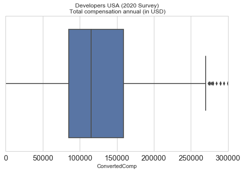

```python
sns.set(context='notebook', style='whitegrid', palette='deep', font='sans-serif', font_scale=1, rc=None)
plt.figure(figsize=[8, 5])
#sns.boxplot(df2020_clean['CompTotal'])
sns.boxplot(y)
plt.xticks(rotation=0, fontsize=15)
plt.yticks(rotation=0, fontsize=15)
plt.xlim([0, 300000])
plt.title("Developers USA (2020 Survey)\n Total compensation annual (in USD)");
plt.show()
```

```python
def linear_mod(X, y, test_size=.3, rand_state=42):
    '''
    INPUT:
    X - a cleaned X matrix (dummy and mean imputation)
    y - a cleaned response (without NANs)
    test_size - a float between [0,1] about what proportion of data should be in the test dataset
    rand_state - an int that is provided as the random state for splitting the data into training and test

    OUTPUT:
    test_score - float - r2 score on the test data
    train_score - float - r2 score on the train data
    lm_model - model object from sklearn
    X_train, X_test, y_train, y_test - output from sklearn train test split used for optimal model

    This function provides the output of a linear machine learning model using the python scikit-learn library
    '''

    #Split into train and test
    X_train, X_test, y_train, y_test = train_test_split(X, y, test_size=test_size, random_state=rand_state)

    lm_model = LinearRegression(normalize=True) # Instantiate
    lm_model.fit(X_train, y_train) #Fit

    #Predict using your model
    y_test_preds = lm_model.predict(X_test)
    y_train_preds = lm_model.predict(X_train)

    #Score using your model
    test_score = r2_score(y_test, y_test_preds)
    train_score = r2_score(y_train, y_train_preds)

    return test_score, train_score, lm_model, X_train, X_test, y_train, y_test
```

Run the ml function with the above dataset

```python
test_score, train_score, lm_model, X_train, X_test, y_train, y_test = linear_mod(X, y)
```

What is the training score?

```python
train_score
```

```
0.5482961857230606
```

What is the test score?

```python
test_score
```

```
0.5306622337278202
```

The ml model explains about half of the volatility in the response variable. It does not overfit, because training score and test score are very close to each other.

### The coefficients of the linear model

We use the space below to take a look at the coefficients.

```python
def coef_weights(coefficients, X_train):
    '''
    INPUT:
    coefficients - the coefficients of the linear model
    X_train - the training data, so the column names can be used
    OUTPUT:
    coefs_df - a dataframe holding the coefficient, estimate, and abs(estimate)

    Provides a dataframe that can be used to understand the most influential coefficients
    in a linear model by providing the coefficient estimates along with the name of the
    variable attached to the coefficient.
    '''
    coefs_df = pd.DataFrame()
    coefs_df['est_int'] = X_train.columns
    coefs_df['coefs'] = lm_model.coef_
    coefs_df['abs_coefs'] = np.abs(lm_model.coef_)
    coefs_df = coefs_df.sort_values('abs_coefs', ascending=False)
    return coefs_df

#Use the function
coef_df = coef_weights(lm_model.coef_, X_train).reset_index(drop=True)

#A quick look at the top results
coef_df.head(10)
```

|  | est_int | coefs | abs_coefs |
| --- | --- | --- | --- |
| 0 | CompFreq_Yearly | -777126.539048 | 777126.539048 |
| 1 | Employment_Employed part-time | -422993.372816 | 422993.372816 |
| 2 | CompFreq_Weekly | 298454.104957 | 298454.104957 |
| 3 | SOVisitFreq_I have never visited Stack Overflo... | -254994.401107 | 254994.401107 |
| 4 | EdLevel_Professional degree (JD, MD, etc.) | 195647.380144 | 195647.380144 |
| 5 | Employment_Independent contractor, freelancer,... | -165203.215789 | 165203.215789 |
| 6 | EdLevel_Primary/elementary school | 111587.649785 | 111587.649785 |
| 7 | OrgSize_Just me - I am a freelancer, sole prop... | -108907.330076 | 108907.330076 |
| 8 | EdLevel_Other doctoral degree (Ph.D., Ed.D., e... | 100339.621381 | 100339.621381 |
| 9 | UndergradMajor_A health science (such as nursi... | -83735.247516 | 83735.247516 |

```python
coef_df.tail()
```

|  | est_int | coefs | abs_coefs |
| --- | --- | --- | --- |
| 152 | Age1stCode | -560.579130 | 560.579130 |
| 153 | SOVisitFreq_Less than once per month or monthly | 547.363191 | 547.363191 |
| 154 | Pandas | 458.393997 | 458.393997 |
| 155 | NEWOnboardGood_Yes | 408.122972 | 408.122972 |
| 156 | Age | 113.981320 | 113.981320 |

### Ranking of coefficients

The index of coefficients **`coef_df`** runs from the coefficient with the highest absolute impact on the salary to the coefficient with the lowest impact.

For example:

> Coefficient No **(1)** *`[Employment_Employed part-time]`* was mapped from the categorical variable `Employment` and the answer option `[Employed part-time]`. It has the second highest impact on the response vector, albeit with a negative sign.

> Interpretation: Developers who are part-time employed tend to have lower salaries.

However, other coefficients with a high (positive) impact are more difficult to interpret.

> Coefficient No. **(6)** *`[EdLevel_Primary/elementary school]`* is the mapping of answer option `[elementary school]` to the question: "Which of the following best describes the highest level of formal education that you have completed?" It is counterintuative to assume that US developers without secondary school and college/university education earn the highest salaries. The respondants who ticked this option might have provided inflated salary figures.

Let us look at the ranking of developer roles.

```python
DevType = ["DevType", "Academic_researcher" , "Scientist" ,"Data_or_business_analyst" ,
           "Data_scientist_or_machine_learning_specialist",
           "Developer_frontend", "Developer_backend", "Developer_fullstack" ,
           "Developer_QA_or_test" , "Developer_desktop_or_enterprise_applications" ,
           "Developer_game_or_graphics" , "Engineer_site_reliability" , "System_administrator" ,
           "DevOps_specialist" , "Developer_embedded_applications_or_devices"  ,
           "Developer_mobile" , "Database_administrator" , "Engineer_data" , "Engineering_manager" ,
           "Educator" , "Marketing_or_sales_professional" ,  "Designer" , "Product_manager", "Senior_executive_VP"]

coef_df[coef_df['est_int'].isin(DevType)] # we filter for rows that contain an element of the list DevType.
```

|  | est_int | coefs | abs_coefs |
| --- | --- | --- | --- |
| 12 | Senior_executive_VP | 70227.942397 | 70227.942397 |
| 14 | Academic_researcher | -67755.690317 | 67755.690317 |
| 21 | Educator | 47407.602117 | 47407.602117 |
| 23 | Scientist | -45797.958721 | 45797.958721 |
| 25 | Product_manager | 42472.280256 | 42472.280256 |
| 33 | Engineer_site_reliability | 32770.124007 | 32770.124007 |
| 36 | Designer | -29647.906758 | 29647.906758 |
| 39 | Developer_QA_or_test | -28586.871323 | 28586.871323 |
| 47 | Data_scientist_or_machine_learning_specialist | 25412.707235 | 25412.707235 |
| 70 | Developer_frontend | 16848.282859 | 16848.282859 |
| 78 | Data_or_business_analyst | 15402.608841 | 15402.608841 |
| 81 | Developer_game_or_graphics | 14664.132889 | 14664.132889 |
| 94 | System_administrator | -11228.194424 | 11228.194424 |
| 98 | Developer_embedded_applications_or_devices | -10827.484117 | 10827.484117 |
| 99 | Marketing_or_sales_professional | 10743.701724 | 10743.701724 |
| 104 | Engineer_data | 8628.030348 | 8628.030348 |
| 113 | Database_administrator | 6665.892227 | 6665.892227 |
| 120 | Developer_fullstack | -6183.278593 | 6183.278593 |
| 121 | DevOps_specialist | -5837.300260 | 5837.300260 |
| 130 | Developer_mobile | -3962.065231 | 3962.065231 |
| 132 | Engineering_manager | 3798.137634 | 3798.137634 |
| 141 | Developer_desktop_or_enterprise_applications | -2429.746884 | 2429.746884 |
| 150 | Developer_backend | 868.745666 | 868.745666 |

</font>

Ranking

> **(12)** **`Senior_executive_VP`** have the highest (positive) impact on the reponse vector of all developer roles (i.e. tend to have high salaries)

> **(14)** **`Academic_researcher`** have the second highest (but negative) impact on the reponse vector (i.e. tend to have lower salaries)

> **(23)** **`Scientist`** have the fourth highest (but negative) impact on the reponse vector (i.e. tend to have lower salaries)

> **(47)** **`Data_scientist_or_machine_learning_specialist`** have the ninth highest (and positive) impact of all developer roles.

> **(78)** **`Data_or_business_analyst`** have the 11th highest (and positive) impact of all developer roles.

> **(150)** **`Developer_backend`** have the lowest (but positive) impact of all developer roles and one of the lowest impact of all coefficients.

Interpretation:

> - Professional developers who perform the roles of **`Senior executive/VP`** have higher expected salaries than developers with other roles. The higher salary forecast might reflect the seniority associated with this job title.
> - **`Academic researcher`** and **`Scientists`** tend to earn lower salaries, presumably because they do not only work for monetary compensation but might still work on their Ph.D. degrees or have prestigious but temporary PostDoc positions.
> - The developer role **`Data scientist / machine learning specialist`** has a *moderately strong impact* on the salary expectation.
> - The developer role **`Data / business analyst`** has a *moderate impact* on the response variabel.
> - The developer role **`Developer backend`** has a *weak impact* on the salary.

</font>

Let us look at the impact of programming languages used by developers:

```python
coef_df[coef_df['est_int'].isin(programming_language2020)]
```

|  | est_int | coefs | abs_coefs |
| --- | --- | --- | --- |
| 19 | Dart; | -49802.394320 | 49802.394320 |
| 22 | Haskell; | -46925.848562 | 46925.848562 |
| 38 | Objective-C; | 28716.679953 | 28716.679953 |
| 40 | Julia; | 28535.990101 | 28535.990101 |
| 42 | Go; | 27345.663849 | 27345.663849 |
| 46 | Scala; | 25641.600163 | 25641.600163 |
| 48 | Rust; | 25077.361922 | 25077.361922 |
| 56 | Python; | -21684.844157 | 21684.844157 |
| 57 | Kotlin; | 21475.612048 | 21475.612048 |
| 59 | JavaScript; | -19778.111940 | 19778.111940 |
| 65 | Swift; | -18549.996647 | 18549.996647 |
| 68 | VBA; | 17258.056280 | 17258.056280 |
| 75 | Ruby; | 15906.116897 | 15906.116897 |
| 79 | Bash/Shell/PowerShell; | 15262.416589 | 15262.416589 |
| 80 | C++; | 14905.995285 | 14905.995285 |
| 82 | Java; | 13864.764817 | 13864.764817 |
| 91 | C; | 11620.050220 | 11620.050220 |
| 92 | PHP; | -11519.726638 | 11519.726638 |
| 101 | Assembly; | -9500.186740 | 9500.186740 |
| 108 | C#; | -8112.914007 | 8112.914007 |
| 115 | SQL; | -6510.460882 | 6510.460882 |
| 126 | TypeScript; | 4658.102003 | 4658.102003 |
| 127 | HTML/CSS; | 4550.962846 | 4550.962846 |
| 143 | R; | 2064.461344 | 2064.461344 |
| 147 | Perl; | 972.887177 | 972.887177 |

</font>

Niche programming languages have a strong impact on salary expectations:

> **(19)** **`Dart`** , **(22)** **`Haskell`** , **(38)** **`Objective-C`** , **(40)** **`Julia`** , **(42)** **`Go`** , **(46)** **`Scala`** and **(48)** **`Rust`**  
> have the highest impact on the reponse vector .

Programming Languages popular with Data Scientists have moderate to weak impacts on salary expectations:

> **(56)** **`Python`** has a *moderately strong (negative) impact* on the salary expectation.

> **(79)** **`Bash/Shell/PowerShell`** has a *moderate (positive) impact* on the salary expectation.

> **(115)** **`SQL`** and **(143)** **`R`** have a *weak impact* on salary.

Programming Languages for Web development have moderate to weak impacts on salary expectations:

> **(59)** **`JavaScript`** has a *moderately strong (negative) impact* on the salary expectation.

> **(126)** **`TypeScript`** and **(127)** **`HTML/CSS`** have a *weak impact* on salary.

</font>

Let us now look at other technologies used by developers:

**MiscTechWorkedWith**:

> Which other frameworks, libraries, and tools have you done extensive development work in over the past year?

```python
coef_df[coef_df['est_int'].isin(MiscTechWorkedWith)]
```

|  | est_int | coefs | abs_coefs |
| --- | --- | --- | --- |
| 30 | Flutter | 37309.641384 | 37309.641384 |
| 34 | Ansible | -30936.006354 | 30936.006354 |
| 41 | Puppet | 28161.662112 | 28161.662112 |
| 43 | Torch/PyTorch | 26463.764627 | 26463.764627 |
| 44 | Keras | 26246.510494 | 26246.510494 |
| 55 | .NET Core | 22107.817386 | 22107.817386 |
| 60 | Chef | 19652.296622 | 19652.296622 |
| 67 | Xamarin | 17891.388825 | 17891.388825 |
| 77 | Cordova | -15499.829587 | 15499.829587 |
| 86 | Teraform | -13242.732217 | 13242.732217 |
| 105 | Unreal Engine | -8305.935705 | 8305.935705 |
| 114 | Apache Spark | -6659.753295 | 6659.753295 |
| 116 | React Native | -6420.857752 | 6420.857752 |
| 122 | Node.js | -5791.950843 | 5791.950843 |
| 129 | Hadoop | 4214.037499 | 4214.037499 |
| 135 | .NET | -3505.484534 | 3505.484534 |
| 140 | TensorFlow | 2774.818107 | 2774.818107 |
| 142 | Unity 3D | -2205.574845 | 2205.574845 |
| 154 | Pandas | 458.393997 | 458.393997 |

</font>

Maschine learning tools:

> **(43)** **`Torch/PyTorch`** and **(44)** **`Keras`** have a *moderately strong (positive) impact* on the salary expectation.

> **(140)** **`TensorFlow`** has the weak impact on the reponse vector .

Big Data tools:

> **(114)** **`Apache Spark`** and **(129)** **`Hadoop`** have a *moderate impact* on the salary expectation.

Data Science tools:

> **(154)** **`Pandas`** has a *very weak impact* on the salary expectation.

</font>

```python
coef_df[coef_df['est_int'].isin(numerical)]
```

|  | est_int | coefs | abs_coefs |
| --- | --- | --- | --- |
| 124 | WorkWeekHrs | 4860.111651 | 4860.111651 |
| 137 | YearsCodePro | 3073.995603 | 3073.995603 |
| 144 | YearsCode | -1385.700569 | 1385.700569 |
| 152 | Age1stCode | -560.579130 | 560.579130 |
| 156 | Age | 113.981320 | 113.981320 |

</font>

Surprisingly, numerical variables have only a weak impact on the response variable.

# VII. Conclusion

> The annual Stack Overflow’s developer survey is the largest survey of software developers in the world, providing us with market trends and with meaningful data of subgroup like **Data Scientists / Machine Learning Specialists**.

> Data Scientist/Machine Learning Specialist frequently perform 3 to 5 additional developer roles as well. Almost half are also **Backend Developers** and 37 % are **Fullstack Developers**. Other popular roles performed are **Data/Business Analyst** (33%) and **Data Engineer** (30%). About a third are **Academic Researchers** or **Scientists**.

> **Python** is by far the most popular programming language for Data Science and Machine Learning. In addition, the relational database language **SQL** is used by 60% of Data Science/Machine Learning Specialists and half use **HTML/CSS** and **JavaScript** for web development. About 40% use **Bash/Shell/PowerShell** for command line Interface and 28% use the **R language** for data analysis. Already 4 % use **Julia**, a language that first appeared in 2012. On average, Data Science/Machine Learning Specialists use 5 programming, scripting, and markup languages and 2 to 3 tools. The most popular tools with Data Science/Machine Learning Specialists are **Pandas**, **Tensorflow**, **Keras**, **Node.js** and **Torch/PyTorch**.

> Niche programming languages like **Dart** or **Julia** have a strong impact on salary expectations. The two programming languages most popular with Data scientists / machine learning specialists, **Python** and **R** , have a moderately strong and a weak impact on the response variable, respectively. Knowledge of command line Interface languages **Bash/Shell/PowerShell** has a moderate impact and proficiency in the relational database language **SQL** has only a weak impact on forecasted salaries.

> Using the machine the learning tools **Torch/PyTorch** and **Keras** have a moderately strong impact on expected salaries, while using the tools **TensorFlow** and **Pandas** only have a weak impact on the reponse variable. However, proficiency in the Big Data tools **Apache Spark** and **Hadoop** have a moderate impact on expected salaries.